# COVID19 UK

Heinrich Peters

4/23/2020

# Prepare data

### Read and format prevalence data

`r`r df_uk_prev <- read_csv(‘UK_timeseries_prep_2005.csv’)

df_uk_prev <- df_uk_prev %>% select(ut_area, date, rate) %>% rename(rate_day = rate) %>% mutate(date = as.Date(date, %d%b%Y))

df_uk_prev2 <- read_csv(‘UK_timeseries_prep_0506_laua_all.csv’)

df_uk_prev2 <- df_uk_prev2 %>% select(laua, date, males, popdens, manufacturing, tourism, health, academic, medage, conservative, airport_dist, medinc, open, extra, agree, neuro, sci, rate) %>% rename(pers_o = open, pers_c = sci, pers_e = extra, pers_a = agree, pers_n = neuro, rate_day = rate, age = medage, male = males, manufact = manufacturing, healthcare = health, academics = academic) %>% mutate(date = as.Date(date, %d%b%Y))

df_uk_prev2 %>% select(-date, -rate_day) %>% distinct() %>% write_csv(‘df_uk_pers_laua.csv’)

df_uk_prev2 %>% select(laua, date, rate_day) %>% write_csv(‘uk_prev_laua.csv’)

### Personality

`r`r df_uk_pers <- read_csv(‘timeseries_uk_utla_march9_april_09.csv’)

df_uk_pers <- df_uk_pers %>% select(ut_area, open, agree, neuro, sci, extra) %>% dplyr::rename(pers_o = open, pers_c = sci, pers_e = extra, pers_a = agree, pers_n = neuro) %>% distinct()

df_uk_pers %>% write_csv(‘df_uk_pers_ut.csv’)

df_uk_pers_nuts <- read_csv(‘UK_socdist_fb_nuts3.csv’)

df_uk_pers_nuts <- df_uk_pers_nuts %>% select(nuts3, open, sci, extra, agree, neuro) %>% dplyr::rename(pers_o = open, pers_c = sci, pers_e = extra, pers_a = agree, pers_n = neuro) %>% distinct()

### Social distancing

`r`r

fb_files <- list.files(‘../FB Data/UK individual files’, ’*.csv’, full.names = T)

df_uk_socdist <- fb_files %>% map(read.csv) %>% bind_rows()

df_uk_socdist <- df_uk_socdist %>% select(ds, all_day_bing_tiles_visited_relative_change, all_day_ratio_single_tile_users, external_polygon_id) %>% rename(date = ds, nuts3 = external_polygon_id, socdist_tiles = all_day_bing_tiles_visited_relative_change, socdist_single_tile = all_day_ratio_single_tile_users) %>% mutate(nuts3 = as.character(nuts3), date = as.Date(date)) %>% arrange(nuts3, date) %>% drop_na()

`r`r df_uk_socdist %>% select(nuts3) %>% distinct() %>% nrow()

```
[1] 175
```

### Controls

`r`r df_uk_ctrl_nuts <- read_csv(_UK_nuts3.csv) df_uk_ctrl_nuts <- df_uk_ctrl_nuts %>% select(-nuts3_name) df_uk_ctrl_nuts <- df_uk_ctrl_nuts %>% rename( age = medage, male = males, manufact = manufacturing, healthcare = health, academics = academic)

df_uk_ctrl_ut <- read_csv(_UK_ut.csv) df_uk_ctrl_ut <- df_uk_ctrl_ut %>% select(-ut_name) df_uk_ctrl_ut <- df_uk_ctrl_ut %>% rename( age = medage, male = males, manufact = manufacturing, healthcare = health, academics = academic)

### Merge prevalence data

`r`r df_uk_prev <- df_uk_prev %>% plyr::join(df_uk_pers, by=‘ut_area’) %>% plyr::join(df_uk_ctrl_ut, by=‘ut_area’)

# create sequence of dates

date_sequence <- seq.Date(min(df_uk_prev$date), max(df_uk_prev$date), 1)

# create data frame with time sequence

df_dates = tibble(date_sequence, 1:length(date_sequence)) names(df_dates) <- c(‘date’, ‘time’)

# merge day index with gps data

df_uk_prev = df_uk_prev %>% merge(df_dates, by=‘date’) %>% arrange(ut_area) %>% as_tibble()

df_uk_prev %>% select(-date, -rate_day, -time) %>% distinct() %>% write_csv(‘df_uk_pers_ut.csv’)

`r`r # create sequence of dates date_sequence <- seq.Date(min(df_uk_prev2$date), max(df_uk_prev2$date), 1)

# create data frame with time sequence

df_dates = tibble(date_sequence, 1:length(date_sequence)) names(df_dates) <- c(‘date’, ‘time’)

# merge day index with gps data

df_uk_prev2 = df_uk_prev2 %>% merge(df_dates, by=‘date’) %>% arrange(laua) %>% as_tibble()

### Merge social distancing data

`r`r df_uk_socdist <- df_uk_socdist %>% plyr::join(df_uk_ctrl_nuts, by=‘nuts3’) %>% plyr::join(df_uk_pers_nuts, by=‘nuts3’)

# create sequence of dates

date_sequence <- seq.Date(min(df_uk_socdist$date), as.Date(‘2020-04-28’), 1)

# create data frame with time sequence

df_dates = tibble(date_sequence, 1:length(date_sequence)) names(df_dates) <- c(‘date’, ‘time’)

# merge day index with gps data

df_uk_socdist = df_uk_socdist %>% inner_join(df_dates, by=‘date’) %>% arrange(nuts3) %>% as_tibble()

df_uk_socdist %>% select(-date, -socdist_tiles, -socdist_single_tile, -time) %>% distinct() %>% write_csv(‘df_uk_pers_nuts.csv’)

### Check timeframes

`r`r df_uk_prev$date %>% summary()

```
        Min.      1st Qu.       Median         Mean      3rd Qu.         Max.
\2020-01-30\ \2020-02-26\ \2020-03-24\ \2020-03-24\ \2020-04-21\ \2020-05-18\
```

`r`r df_uk_socdist$date %>% summary()

```
        Min.      1st Qu.       Median         Mean      3rd Qu.         Max.
\2020-03-01\ \2020-03-15\ \2020-03-30\ \2020-03-30\ \2020-04-14\ \2020-04-28\
```

### Control for weekend effect in social distancing

`r`r easter <- seq.Date(as.Date(‘2020-04-10’), as.Date(‘2020-04-13’), 1)

df_uk_loess <- df_uk_socdist %>% mutate(weekday = format(date, ‘%u’)) %>% filter(!(weekday %in% c(‘6’,‘7’) | date %in% easter)) %>% split(.$nuts3) %>% map(~ loess(socdist_single_tile ~ time, data = .)) %>% map(predict, 1:max(df_uk_socdist$time)) %>% bind_rows() %>% gather(key = ‘nuts3’, value = ‘loess’) %>% group_by(nuts3) %>% mutate(time = row_number())

df_uk_loess_2 <- df_uk_socdist %>% mutate(weekday = format(date, ‘%u’)) %>% filter(!(weekday %in% c(‘6’,‘7’) | date %in% easter)) %>% split(.$nuts3) %>% map(~ loess(socdist_tiles ~ time, data = .)) %>% map(predict, 1:max(df_uk_socdist$time)) %>% bind_rows() %>% gather(key = ‘nuts3’, value = ‘loess’) %>% rename(loess_2 = loess) %>% group_by(nuts3) %>% mutate(time = row_number())

df_uk_socdist <- df_uk_socdist %>% merge(df_uk_loess, by=c(‘nuts3’, ‘time’)) %>% merge(df_uk_loess_2, by=c(‘nuts3’, ‘time’)) %>% mutate(weekday = format(date, ‘%u’)) %>% mutate(socdist_single_tile_clean = ifelse(weekday %in% c(‘6’,‘7’) | date %in% easter, loess, socdist_single_tile), socdist_tiles_clean = ifelse(weekday %in% c(‘6’,‘7’) | date %in% easter, loess_2, socdist_tiles)) %>% arrange(nuts3, time) %>% select(-weekday)

df_uk_socdist <- df_uk_socdist %>% drop_na() %>% mutate(time = time-1)

### Pick cleaned social distancing metrics

`r`r

df_uk_socdist <- df_uk_socdist %>% mutate(socdist_single_tile = socdist_single_tile_clean, socdist_tiles = socdist_tiles_clean) %>% select(-loess, -loess_2, -socdist_single_tile_clean, -socdist_tiles_clean)

### Rescale Data

`r`r lvl2_scaled_ut <- df_uk_prev %>% dplyr::select(-time, -date, -rate_day) %>% distinct() %>% mutate_at(vars(-ut_area), scale)

lvl1_scaled_ut <- df_uk_prev %>% select(ut_area, date, time, rate_day)

df_uk_prev_scaled <- plyr::join(lvl1_scaled_ut, lvl2_scaled_ut, by = ‘ut_area’)

`r`r lvl2_scaled_laua <- df_uk_prev2 %>% dplyr::select(-time, -date, -rate_day) %>% distinct() %>% mutate_at(vars(-laua), scale)

lvl1_scaled_laua <- df_uk_prev2 %>% select(laua, date, time, rate_day)

df_uk_prev2_scaled <- plyr::join(lvl1_scaled_laua, lvl2_scaled_laua, by = ‘laua’)

`r`r lvl2_scaled_nuts <- df_uk_socdist %>% dplyr::select(-time, -date, -socdist_tiles, -socdist_single_tile) %>% distinct() %>% mutate_at(vars(-nuts3), scale)

lvl1_scaled_nuts <- df_uk_socdist %>% select(nuts3, date, time, socdist_single_tile, socdist_tiles) %>% mutate_at(vars(-nuts3, -time), scale)

df_uk_socdist_scaled <- plyr::join(lvl1_scaled_nuts, lvl2_scaled_nuts, by = ‘nuts3’)

# Define outcomes of interest

### COVID - Extract onset UT level

`r`r # get onset day df_uk_onset_prev <- df_uk_prev_scaled %>% group_by(ut_area) %>% mutate(rate = rate_day-lag(rate_day)) %>% drop_na() %>% mutate(rate_cs = cumsum(rate)) %>% filter(rate_cs > 0.1) %>% summarize(onset_prev = min(time))

# merge with county data

df_uk_onset_prev <- df_uk_prev_scaled %>% select(-time, -date, -rate_day) %>% distinct() %>% left_join(df_uk_onset_prev, by = ‘ut_area’)

# handle censored data

df_uk_onset_prev <- df_uk_onset_prev %>% mutate(event = ifelse(is.na(onset_prev), 0, 1)) %>% mutate(onset_prev = replace_na(onset_prev, as.numeric(diff(range(df_uk_prev$date)))+1))

df_uk_onset_prev$onset_prev %>% hist()

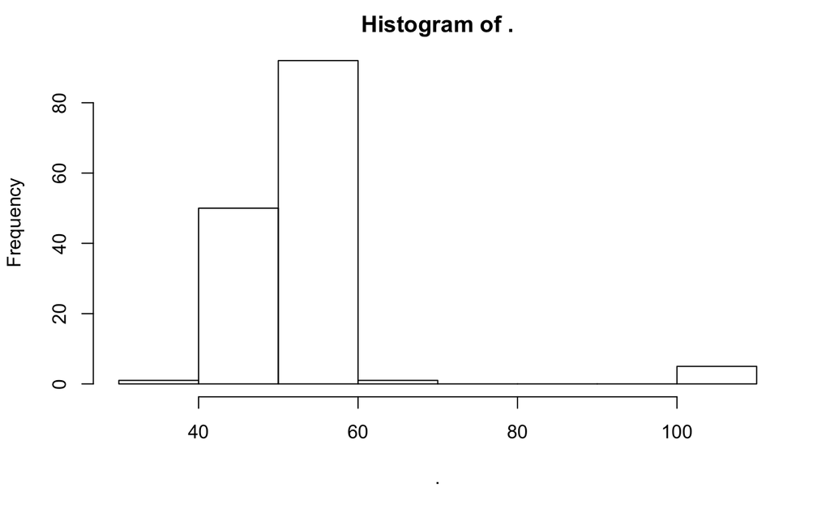

`r`r df_uk_onset_prev$onset_prev %>% mean()

```
[1] 53.98658
```

### Extract slopes

`r`r # cut time series before onset df_uk_prev_scaled <- df_uk_prev_scaled %>% group_by(ut_area) %>% mutate(rate = rate_day-lag(rate_day)) %>% drop_na() %>% mutate(rate_cs = cumsum(rate)) %>% filter(rate_cs > 0.1) %>% mutate(time = time-min(time)+1) %>% ungroup() %>% filter(time <= 30) %>% select(-rate_cs)

# extract slope prevalence

df_uk_slope_prev <- df_uk_prev_scaled %>% split(.$ut_area) %>% map(~ lm(log(rate_day+1) ~ time, data = .)) %>% map(coef) %>% map_dbl(‘time’) %>% as.data.frame() %>% rownames_to_column(‘ut_area’) %>% rename(slope_prev = ‘.’)

# merge with county data

df_uk_slope_prev <- df_uk_onset_prev %>% inner_join(df_uk_slope_prev, by = ‘ut_area’) %>% drop_na()

# standardize slopes

df_uk_slope_prev <- df_uk_slope_prev %>% mutate(slope_prev = scale(slope_prev), onset_prev = scale(onset_prev))

### Explore distributions

`r`r df_uk_onset_prev %>% ggplot(aes(onset_prev)) + geom_histogram()

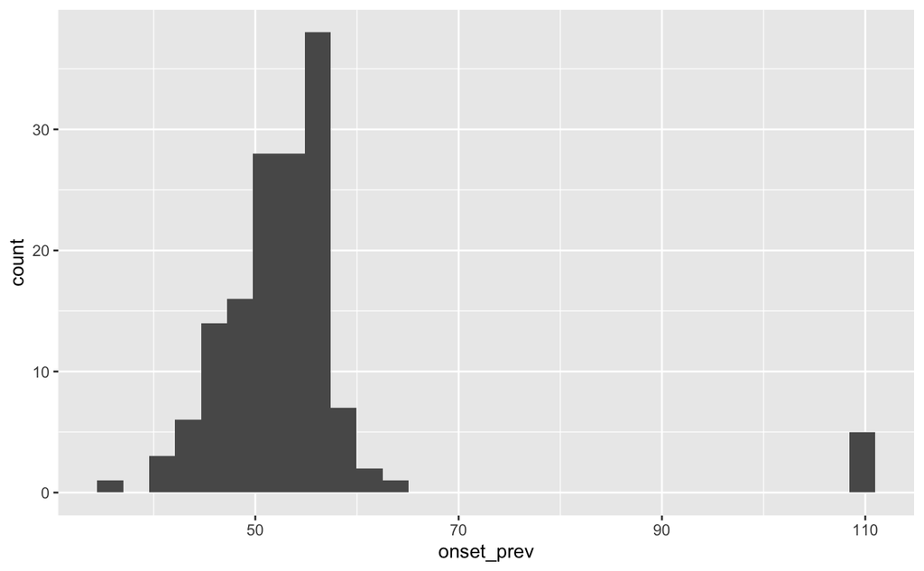

`r`r df_uk_slope_prev %>% ggplot(aes(slope_prev)) + geom_histogram()

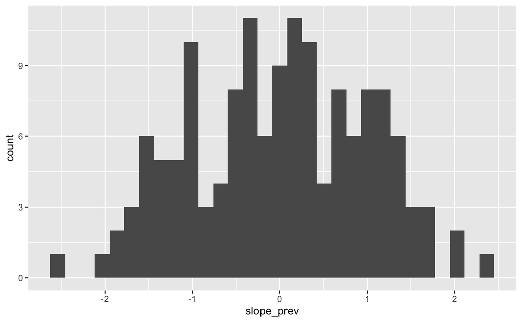

### Extract COVID onset - LAD level

`r`r

# get onset day

df_uk_onset_prev_laua <- df_uk_prev2_scaled %>% group_by(laua) %>% mutate(rate = rate_day-lag(rate_day)) %>% drop_na() %>% mutate(rate_cs = cumsum(rate)) %>% filter(rate_cs > 0.1) %>% summarize(onset_prev = min(time))

# merge with county data

df_uk_onset_prev_laua <- df_uk_prev2_scaled %>% select(-time, -date, -rate_day) %>% distinct() %>% left_join(df_uk_onset_prev_laua, by = ‘laua’)

# handle censored data

df_uk_onset_prev_laua <- df_uk_onset_prev_laua %>% mutate(event = ifelse(is.na(onset_prev), 0, 1)) %>% mutate(onset_prev = replace_na(onset_prev, as.numeric(diff(range(df_uk_prev2$date)))+1))

### Extract slopes

`r`r

# cut time series before onset

df_uk_prev2_scaled <- df_uk_prev2_scaled %>% group_by(laua) %>% mutate(rate = rate_day-lag(rate_day)) %>% drop_na() %>% mutate(rate_cs = cumsum(rate)) %>% filter(rate_cs > 0.1) %>% mutate(time = time-min(time)+1) %>% ungroup() %>% filter(time <= 30) %>% select(-rate_cs)

# extract slope prevalence

df_uk_slope_prev_laua <- df_uk_prev2_scaled %>% split(.$laua) %>% map(~ lm(log(rate_day+1) ~ time, data = .)) %>% map(coef) %>% map_dbl(‘time’) %>% as.data.frame() %>% rownames_to_column(‘laua’) %>% rename(slope_prev = ‘.’)

# merge with county data

df_uk_slope_prev_laua <- df_uk_onset_prev_laua %>% left_join(df_uk_slope_prev_laua, by = ‘laua’) %>% mutate(slope_prev = replace_na(slope_prev, 0))

# standardize slopes

df_uk_slope_prev_laua <- df_uk_slope_prev_laua %>% mutate(slope_prev = scale(slope_prev), onset_prev = scale(onset_prev))

### Explore distributions

`r`r df_uk_onset_prev_laua %>% ggplot(aes(onset_prev)) + geom_histogram()

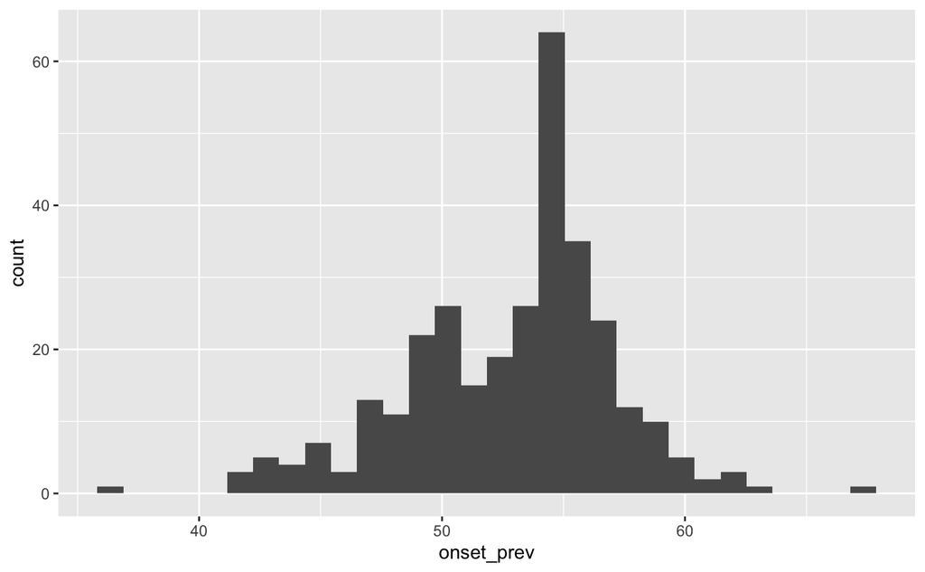

`r`r df_uk_slope_prev_laua %>% ggplot(aes(slope_prev)) + geom_histogram()

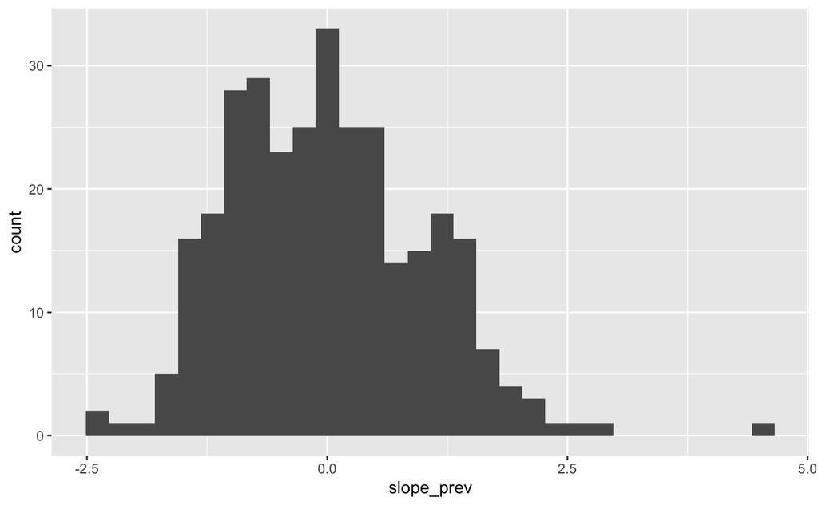

### Social Distancing - Change point analysis

`r`r # keep only counties with full data nuts_complete <- df_uk_socdist_scaled %>% group_by(nuts3) %>% summarize(n = n()) %>% filter(n==max(.$n)) %>% .$nuts3

# run changepoint analysis

df_uk_socdist_cpt_results <- df_uk_socdist_scaled %>% select(nuts3, socdist_single_tile) %>% filter(nuts3 %in% nuts_complete) %>% split(.$nuts3) %>% map(~ cpt.meanvar(as.vector(.$socdist_single_tile), #penalty = ‘Asymptotic’, class=TRUE, param.estimates=TRUE, Q=1, test.stat = ‘Normal’))

df_uk_socdist_cpt_results_2 <- df_uk_socdist_scaled %>% select(nuts3, socdist_tiles) %>% filter(nuts3 %in% nuts_complete) %>% split(.$nuts3) %>% map(~ cpt.meanvar(as.vector(.$socdist_tiles), #penalty = ‘Asymptotic’, class=TRUE, param.estimates=TRUE, Q=1, test.stat = ‘Normal’))

# calculate change point

df_uk_socdist_cpt_day <- df_uk_socdist_cpt_results %>% map(cpts) %>% unlist() %>% as.data.frame() %>% rename(cpt_day_socdist = ‘.’) %>% rownames_to_column(‘nuts3’)

df_uk_socdist_cpt_day_2 <- df_uk_socdist_cpt_results_2 %>% map(cpts) %>% unlist() %>% as.data.frame() %>% rename(cpt_day_socdist_2 = ‘.’) %>% rownames_to_column(‘nuts3’)

# calculate mean differences

df_uk_socdist_cpt_mean_diff <- df_uk_socdist_cpt_results %>% map(param.est) %>% map(~ .$mean) %>% map(~ .[2]) %>% unlist() %>% as.data.frame() %>% rename(mean_diff_socdist = ‘.’) %>% rownames_to_column(‘nuts3’)

df_uk_socdist_cpt_mean_diff_2 <- df_uk_socdist_cpt_results_2 %>% map(param.est) %>% map(~ .$mean) %>% map(~ -.[2]) %>% unlist() %>% as.data.frame() %>% rename(mean_diff_socdist_2 = ‘.’) %>% rownames_to_column(‘nuts3’)

# calculate means

df_uk_socdist_mean <- df_uk_socdist_scaled %>% group_by(nuts3) %>% summarize(mean_socdist = mean(socdist_single_tile))

df_uk_socdist_mean_2 <- df_uk_socdist_scaled %>% group_by(nuts3) %>% summarize(mean_socdist_2 = -mean(socdist_tiles))

# merge with county data

nuts_ut_key <- read_csv(‘nuts3_ut.csv’)

`r`r df_uk_cpt_socdist <- df_uk_socdist_scaled %>% select(-time, -date, -socdist_single_tile, -socdist_tiles) %>% distinct() %>% left_join(df_uk_socdist_cpt_day, by=‘nuts3’) %>% left_join(df_uk_socdist_cpt_day_2, by=‘nuts3’) %>% left_join(df_uk_socdist_cpt_mean_diff, by=‘nuts3’) %>% left_join(df_uk_socdist_cpt_mean_diff_2, by=‘nuts3’) %>% left_join(df_uk_socdist_mean, by=‘nuts3’) %>% left_join(df_uk_socdist_mean_2, by=‘nuts3’) %>% left_join(nuts_ut_key, by=‘nuts3’) %>% left_join(select(df_uk_onset_prev, ut_area, onset_prev), by=‘ut_area’) %>% left_join(select(df_uk_slope_prev, ut_area, slope_prev), by=‘ut_area’) %>% select(-ut_area)

# standardize mean/var differences

df_uk_cpt_socdist <- df_uk_cpt_socdist %>% mutate(mean_diff_socdist = scale(mean_diff_socdist), mean_diff_socdist_2 = scale(mean_diff_socdist_2), mean_socdist = scale(mean_socdist), mean_socdist_2 = scale(mean_socdist_2))

# handle censored data

df_uk_cpt_socdist <- df_uk_cpt_socdist %>% mutate(cpt_day_socdist = ifelse(is.na(cpt_day_socdist), as.numeric(diff(range(df_uk_cpt_socdist$date))), cpt_day_socdist)) %>% mutate(event = ifelse(cpt_day_socdist >= as.numeric(diff(range(df_uk_socdist$date))), 0, 1))

`r`r df_uk_cpt_socdist$cpt_day_socdist %>% hist()

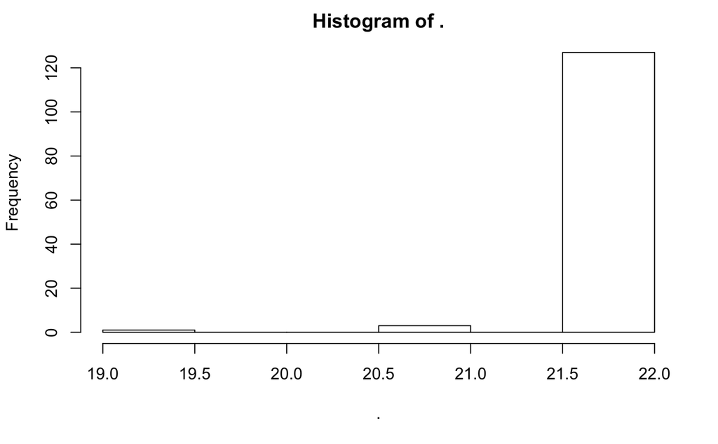

`r`r df_uk_cpt_socdist$mean_diff_socdist %>% hist()

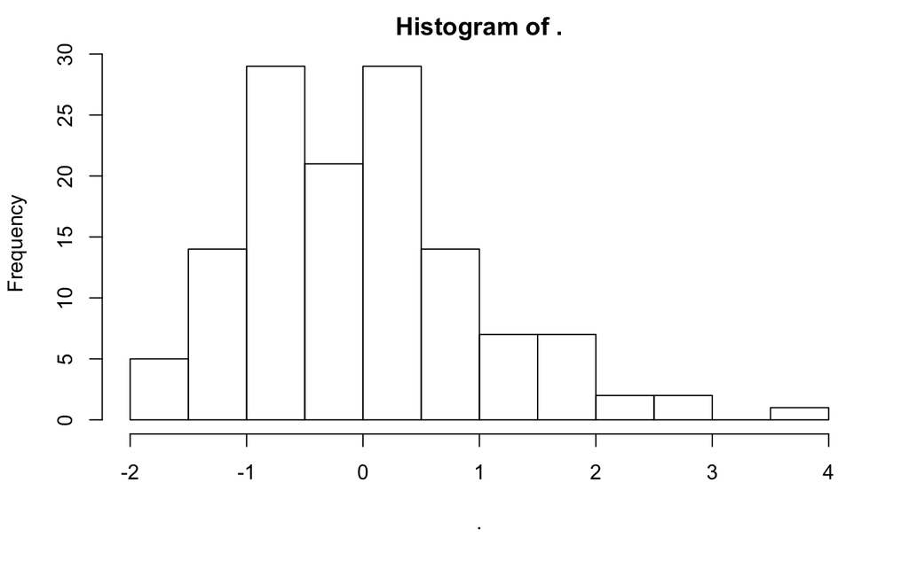

`r`r df_uk_cpt_socdist$mean_socdist %>% hist()

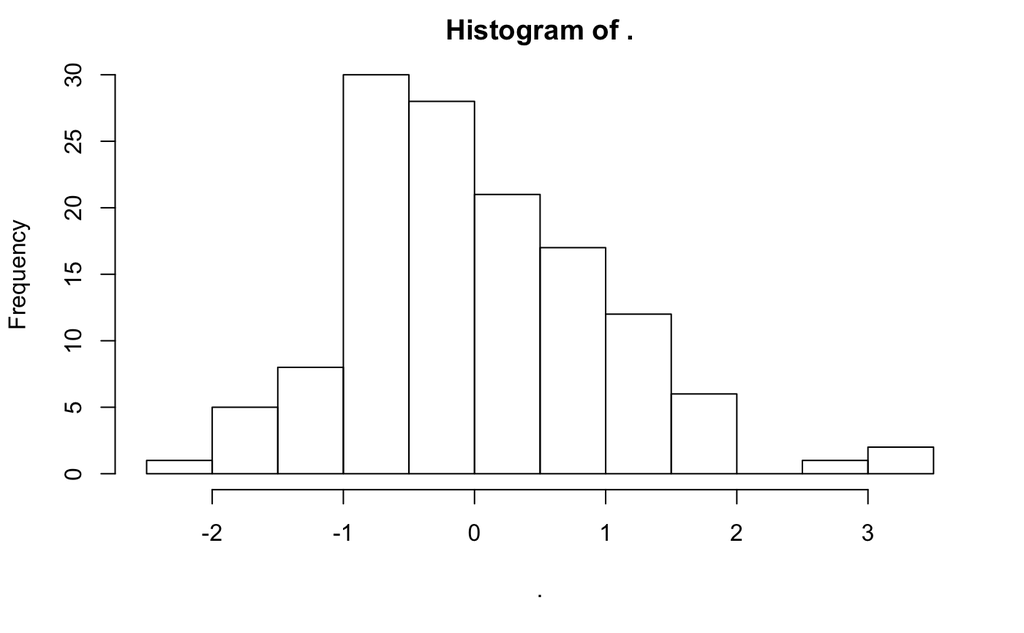

`r`r

df_uk_cpt_socdist$cpt_day_socdist_2 %>% hist()

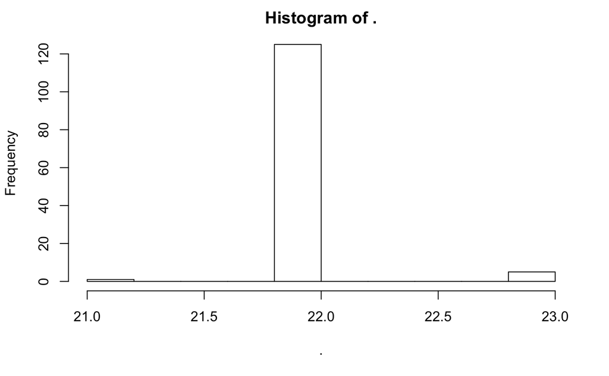

`r`r df_uk_cpt_socdist$mean_diff_socdist_2 %>% hist()

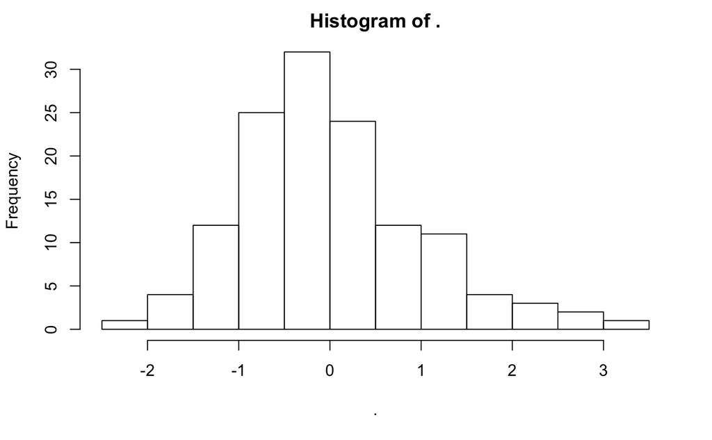

`r`r df_uk_cpt_socdist$mean_socdist_2 %>% hist()

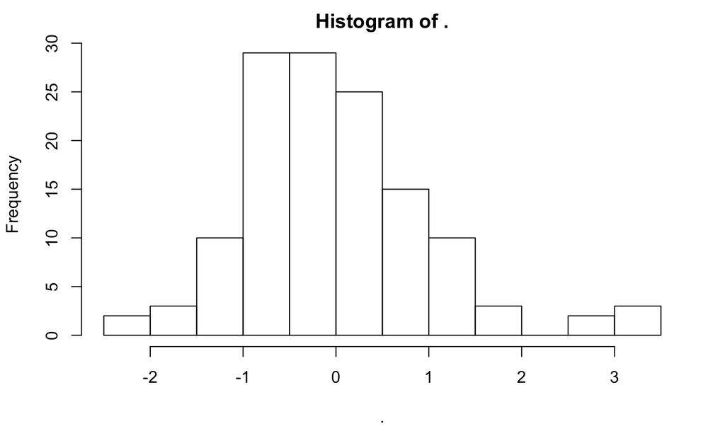

`r`r

for(i in head(df_uk_socdist_cpt_results, 5)){ plot(i) }

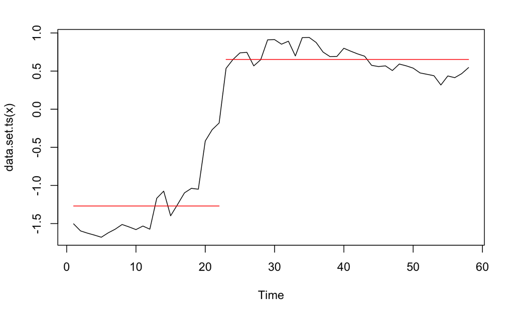

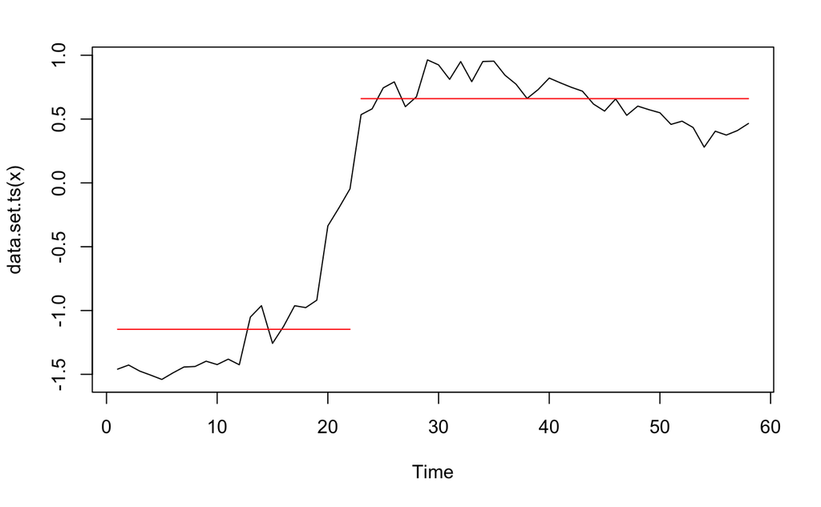

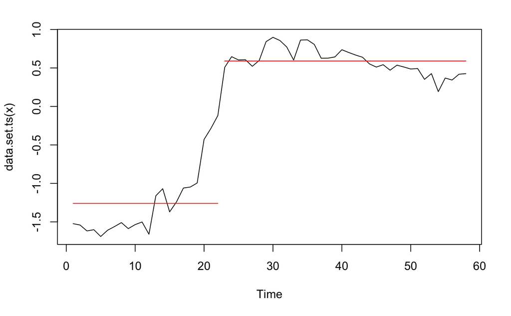

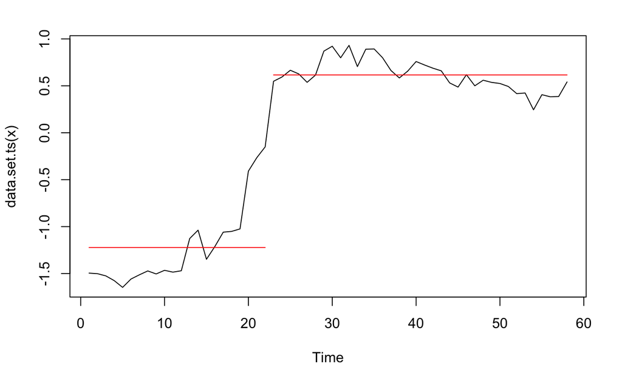

`r`r NA

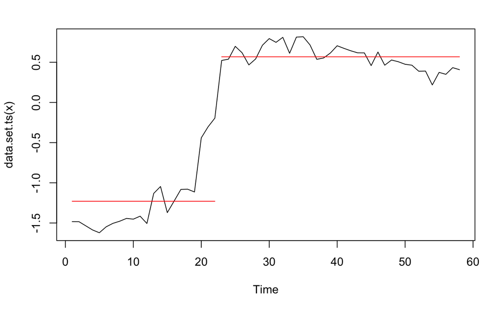

`r`r

for(i in head(df_uk_socdist_cpt_results_2, 5)){ plot(i) }

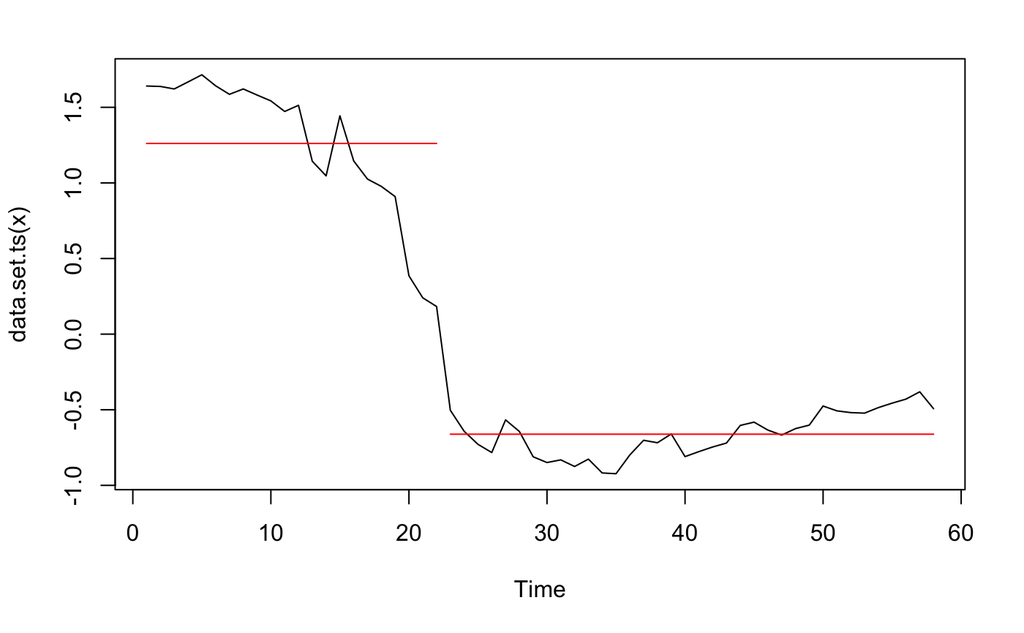

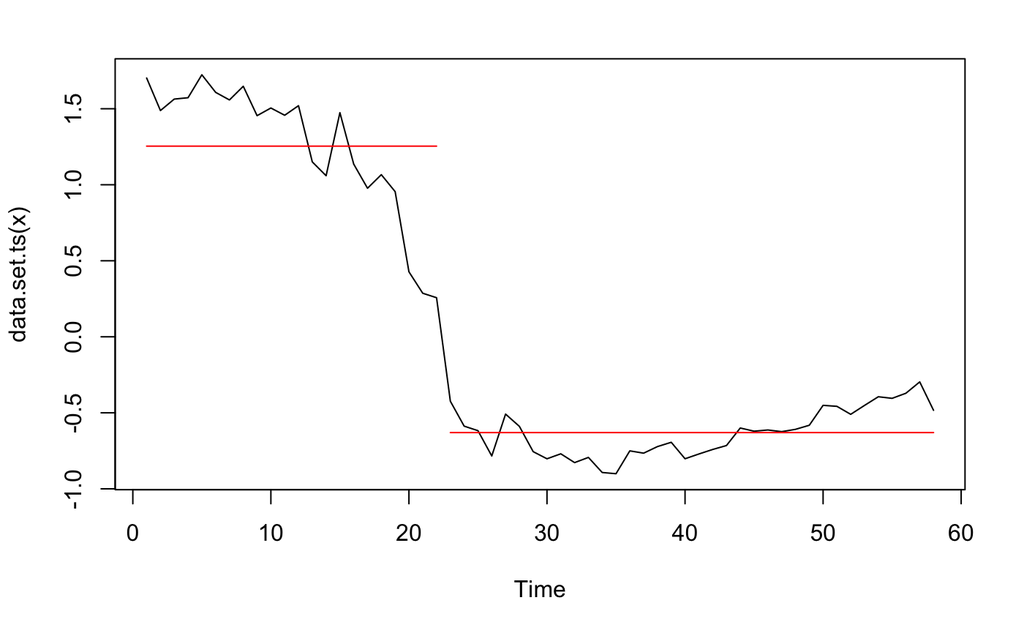

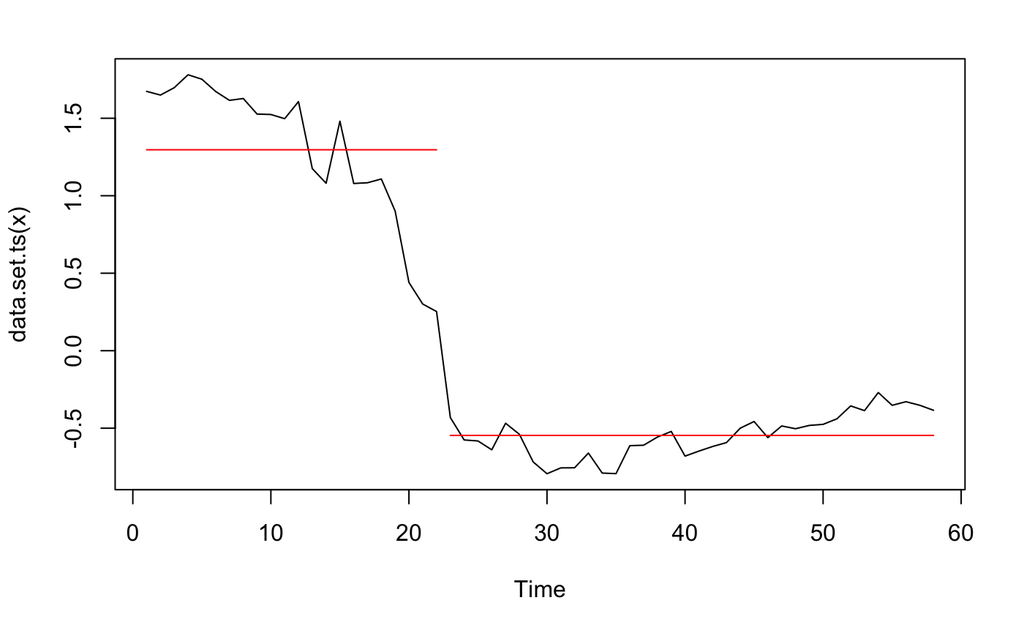

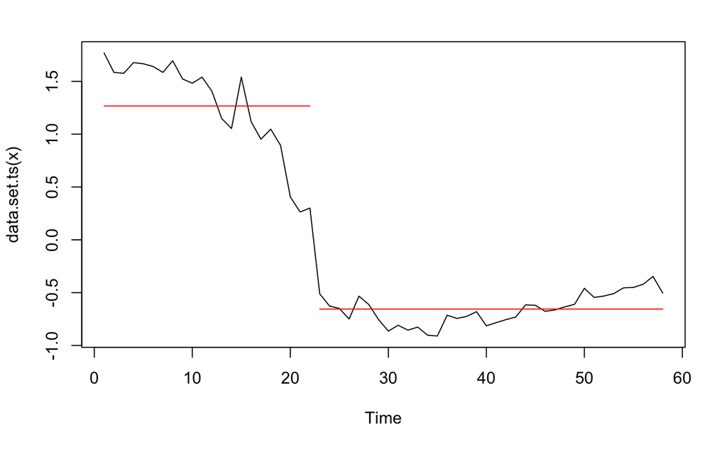

`r`r NA

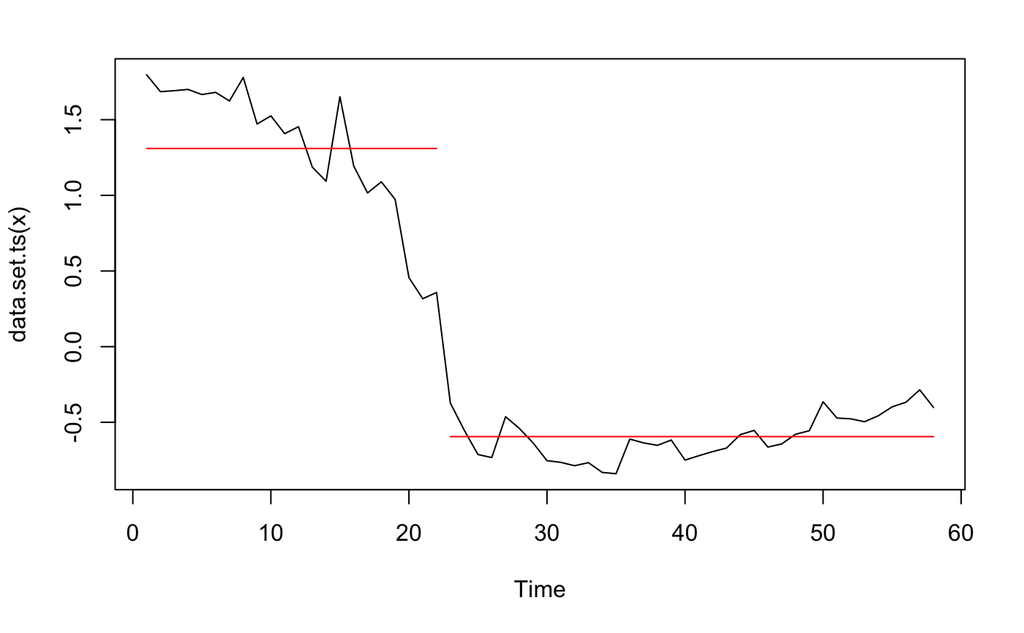

# Fit models

### Predict COVID onset

`r`r uk_cox_prev_onset <- run_analyses(y = ‘onset_prev’, data = df_uk_slope_prev_laua, model = ‘cox’)

### Predict COVID growth

`r`r uk_lm_prev_slope <- run_analyses(y = ‘slope_prev’, data = df_uk_slope_prev_laua, model = ‘lm’)

### Predict socdist change points

`r`r uk_cox_socdist_cpt <- run_analyses(y = ‘cpt_day_socdist_2’, data = df_uk_cpt_socdist, model = ‘cox’)

### Predict socdist means

`r`r uk_lm_socdist_mean <- run_analyses(y = ‘mean_socdist_2’, data = df_uk_cpt_socdist, model = ‘lm’)

# Export data

`r`r

uk_list_results <- list(uk_cox_prev_onset, uk_lm_prev_slope, uk_cox_socdist_cpt, uk_lm_socdist_mean)

uk_results_names <- list(‘uk_cox_prev_onset’, ‘uk_lm_prev_slope’, ‘uk_cox_socdist_cpt’, ‘uk_lm_socdist_mean’)

names(uk_list_results) <- uk_results_names

save(uk_list_results, file=_list_results.RData)

# Extract results

### Results - predict COVID onset

`r`r uk_agg_prev_onset <- uk_list_results$uk_cox_prev_onset %>% extract_all()

### Results - predict COVID growth

`r`r uk_agg_prev_slope <- uk_list_results$uk_lm_prev_slope %>% extract_all()

### Results - predict socdist start

`r`r uk_agg_socdist_cpt <- uk_list_results$uk_cox_socdist_cpt %>% extract_all()

### Results - predict socdist means

`r`r uk_agg_socdist_mean <- uk_list_results$uk_lm_socdist_mean %>% extract_all()

### Save aggregated results

`r`r uk_agg <- list(uk_agg_prev_onset, uk_agg_prev_slope, uk_agg_socdist_cpt, uk_agg_socdist_mean )

names(uk_agg) <- uk_results_names

save(uk_agg, file=_agg.RData)

uk_agg

| trait | model | coef | se | p | stars |
| --- | --- | --- | --- | --- | --- |
| pers_o | base | 0.280362478 | 0.07117752 | 8.184957e-05 | *** |
| pers_o | soc | 0.008906084 | 0.10898448 | 9.348703e-01 |  |
| pers_o | econ | 0.014858570 | 0.09075567 | 8.699511e-01 |  |
| pers_o | prev | -0.068704230 | 0.07614288 | 3.668940e-01 |  |
| pers_o | all | -0.150687281 | 0.11577458 | 1.930677e-01 |  |
| pers_c | base | -0.224362903 | 0.06125313 | 2.493949e-04 | *** |
| pers_c | soc | 0.041399553 | 0.08338724 | 6.195604e-01 |  |
| pers_c | econ | -0.226796274 | 0.06476607 | 4.621674e-04 | *** |
| pers_c | prev | 0.096985912 | 0.07583421 | 2.009251e-01 |  |
| pers_c | all | 0.063292228 | 0.09484289 | 5.045565e-01 |  |

[output cut: 15 more lines]

| trait | model | coef | se | p | stars |
| --- | --- | --- | --- | --- | --- |
| pers_o | base | 0.116909269 | 0.05640671 | 3.903451e-02 | * |
| pers_o | soc | 0.039143269 | 0.08399683 | 6.415396e-01 |  |
| pers_o | econ | 0.130887890 | 0.07125172 | 6.717960e-02 |  |
| pers_o | prev | -0.127523240 | 0.07016594 | 7.012585e-02 |  |
| pers_o | all | -0.100150343 | 0.09656921 | 3.005321e-01 |  |
| pers_c | base | -0.447003125 | 0.05080603 | 9.884939e-17 | *** |
| pers_c | soc | -0.390253602 | 0.06945153 | 4.308716e-08 | *** |
| pers_c | econ | -0.445207875 | 0.05235480 | 8.162686e-16 | *** |
| pers_c | prev | -0.319584489 | 0.06680918 | 2.682404e-06 | *** |
| pers_c | all | -0.360259645 | 0.07776618 | 5.389030e-06 | *** |

[output cut: 15 more lines]

| trait | model | coef | se | p | stars |
| --- | --- | --- | --- | --- | --- |
| pers_o | base | -0.004428940 | 0.08059440 | 0.9561756 |  |
| pers_o | soc | -0.044374785 | 0.17698079 | 0.8020212 |  |
| pers_o | econ | 0.021446353 | 0.12443683 | 0.8631645 |  |
| pers_o | prev | 0.033689324 | 0.14815887 | 0.8201232 |  |
| pers_o | all | -0.096387403 | 0.24407622 | 0.6929115 |  |
| pers_c | base | 0.004425975 | 0.08818707 | 0.9599722 |  |
| pers_c | soc | -0.081341285 | 0.15397620 | 0.5973107 |  |
| pers_c | econ | -0.020765144 | 0.09982115 | 0.8352106 |  |
| pers_c | prev | 0.020915320 | 0.13866992 | 0.8801113 |  |
| pers_c | all | 0.009830681 | 0.19862392 | 0.9605257 |  |

[output cut: 15 more lines]

```
NA
```

| trait | model | coef | se | p | stars |
| --- | --- | --- | --- | --- | --- |
| pers_o | base | 0.66377843 | 0.06585150 | 5.593395e-18 | *** |
| pers_o | soc | 0.18217523 | 0.11466154 | 1.146098e-01 |  |
| pers_o | econ | 0.21556091 | 0.07160246 | 3.151416e-03 | ** |
| pers_o | prev | 0.19510462 | 0.09387458 | 3.972262e-02 | * |
| pers_o | all | -0.01992786 | 0.11097901 | 8.578079e-01 |  |
| pers_c | base | -0.46969577 | 0.07772870 | 1.517064e-08 | *** |
| pers_c | soc | 0.10321394 | 0.09640663 | 2.863912e-01 |  |
| pers_c | econ | -0.18190013 | 0.05398827 | 1.000555e-03 | ** |
| pers_c | prev | 0.20542358 | 0.08045802 | 1.187681e-02 | * |
| pers_c | all | -0.02891620 | 0.09106457 | 7.514084e-01 |  |

[output cut: 15 more lines]

`r`r

write_csv(df_uk_slope_prev, ‘/Users/hp2500/Google Drive/STUDY/Columbia/Research/Corona/Delivery/df_uk_slope_prev.csv’) write_csv(df_uk_cpt_socdist, ‘/Users/hp2500/Google Drive/STUDY/Columbia/Research/Corona/Delivery/df_uk_cpt_socdist.csv’)